# Posgrado Estadistica 2025

Material del curso de Posgrado de Experimentación y Métodos Estadísticos en MCF

## INTRODUCCION

La materia “Experimentación y Métodos Estadísticos” está diseñada para proporcionar a los estudiantes herramientas fundamentales para el análisis e interpretación de datos experimentales. A lo largo del curso, se aprende a importar y manipular datos, calcular estadísticos descriptivos, y visualizar la información mediante gráficos como boxplots, barplots y violín. Asimismo, se aplican diversas pruebas estadísticas, incluyendo t-tests, ANOVA, pruebas post-hoc y regresión lineal, así como métodos para evaluar supuestos de normalidad y homocedasticidad.

Esta materia combina teoría y práctica, permitiendo a los estudiantes desarrollar habilidades para diseñar experimentos, comparar tratamientos y tomar decisiones basadas en evidencia estadística.

## OBJETIVOS

✌️General: Comprender y aplicar métodos estadísticos para el análisis de datos experimentales

👍Específicos:

🧩 Diseñar y analizar experimentos

🧩 Aplicar pruebas estadísticas apropiadas según los datos

🧩 Interpretar resultados y comunicar conclusiones de manera clara

🧩 Evaluar supuestos estadísticos y calcular tamaños del efecto

## Contenido del curso

**Semana 1** (07/08/2025): Inicio del curso :fire: + Crear repositorio + Sincronizar nube y computadora + Credenciales Git

**Semana 2** (14/08/2025): Primer contacto con R y conocimiento de variables cuantitativas y cualitativas

**Semana 3** (21/08/2025): Importar y explorar datos, renombrar columnas, calcular medias, crear subconjuntos y generar gráficas (boxplot y barplot) para visualizar variabilidad y tendencias

**Semana 4** (28/08/2025): Explorar datos, calcular estadísticos, evaluar normalidad y varianzas, comparar tratamientos con t-test, generar gráficas y calcular el tamaño del efecto (Cohen’s d)

**Semana 5** (04/09/2025): Importar y explorar data frames, calcular medias, visualizar con boxplot y realizar pruebas t pareadas para comparar producción entre años, evaluando hipótesis y varianzas

**Semana 6** (11/09/2025): Trabajo con data frames, crear subconjuntos, eliminar factores innecesarios, visualizar con boxplot y comparar medias entre especies usando t-test

**Semana 7** (18/09/2025): Convertir factores, visualizar con boxplot y violín, evaluar normalidad y varianzas, realizar ANOVA y pruebas post-hoc (LSD y Tukey) para comparar tratamientos

**Semana 8** (25/09/2025): Calcular regresión lineal manual y con lm, obtener valores ajustados y residuos, realizar ANOVA y probar homocedasticidad con Breusch-Pagan.

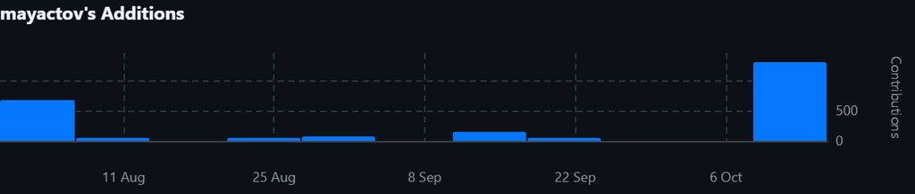

contribuciones